# 공간통계를 위한 데이터 사이언스

지도 데이터: `GADM` - 행정 지도

[Tidyverse Korea](https://www.facebook.com/groups/tidyverse/)

Tidyverse Korea

2020-09-06

# 1 행정지도 데이터

[GADM maps and data](https://gadm.org/index.html)은 전세계 모든 국가 행정구역을 지도에 담고 있다. 이를 직접 웹사이트에서 다운로드 받아도 좋지만 [`GADMTools: Easy Use of 'GADM' Maps`](https://cran.r-project.org/web/packages/GADMTools/) 팩키지를 사용하면 수월하게 활용이 가능하다.

## 1.1 설치

CRAN에 등록되어 있어 [`GADMTools`](https://cran.r-project.org/web/packages/GADMTools/)를 설치하면 된다.

```r
install.packages("GADMTools")
```

## 1.2 헬로월드

`maps` 팩키지에 내장된 전세계 도시 정보를 바탕으로 이야기를 풀어가자.

```r
library(countrycode)
library(GADMTools)
library(tidyverse)
library(sf)

world_cities <- maps::world.cities %>%
  as_tibble()

korea_cities <- world_cities %>%
  filter(str_detect(country.etc, "[Kk]orea South")) %>%
  mutate(pop = pop / 10^4)

korea_cities
```

```
# A tibble: 132 x 6
   name        country.etc   pop   lat  long capital
   <chr>       <chr>       <dbl> <dbl> <dbl>   <int>
 1 Aewol       Korea South  2.41  33.5  126.       0
 2 Andong      Korea South 13.0   36.6  129.       0
 3 Angang      Korea South  3.50  36.0  129.       0
 4 Ansan       Korea South 66.9   37.4  127.       0
 5 Ansong      Korea South  7.30  37.0  127.       0
 6 Anyang      Korea South 64.3   37.4  127.       0
 7 Asan        Korea South 10.2   36.8  127.       0
 8 Changsungpo Korea South  5.71  34.9  129.       0
 9 Changwon    Korea South 53.6   35.3  129.       0
10 Chechon     Korea South 12.3   37.1  128.       0
# ... with 122 more rows
```

대한민국 지도를 다운로드 받아 `shapefliles/` 디렉토리로 이동시킨다.

```r
dir.create("shapefiles")
sigungu_shp <- gadm_sp_loadCountries(fileNames = 'KOR', level = 2, basefile = './shapefiles', simplify=0.01)
fs::file_move("./shapefilesKOR_adm2.rds", "shapefiles/")
```

다운로드 받은 shapefile을 불러와서 이를 시각화해서 제대로 다운로드 받았는지 확인한다.

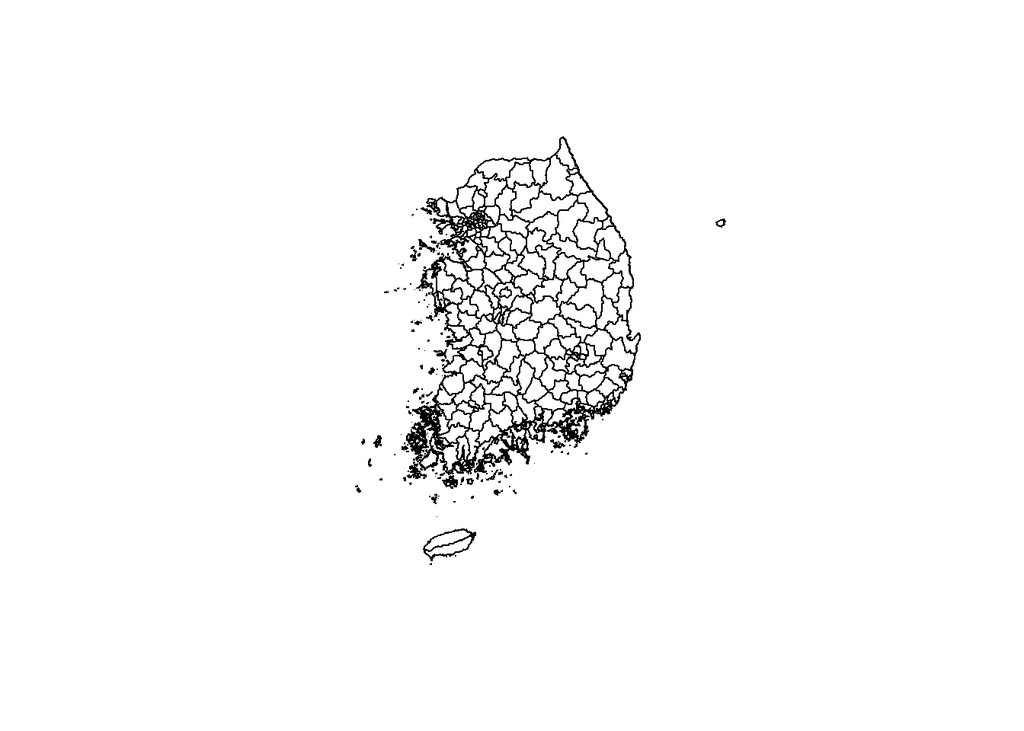

```r
sigungu_shp <- read_rds("shapefiles/shapefilesKOR_adm2.rds")

sigungu_shp$NL_NAME_1 <- iconv(sigungu_shp$NL_NAME_1, from = "CP949", to = "UTF-8", sub = NA, mark = TRUE, toRaw = FALSE)

plot(sigungu_shp)
```

다음으로 `shapefile`을 `sf` 객체로 변환시킨 후에 `ggplot`을 지도를 시각화하고 인구를 `geom_point()`로 지도위에 올린다.

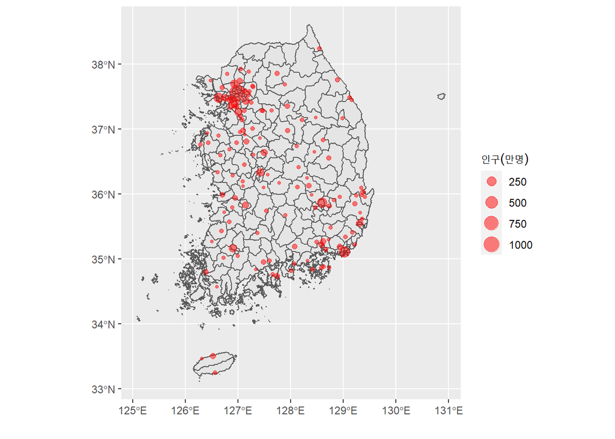

```r
sigungu_sf <- st_as_sf(sigungu_shp)

ggplot(sigungu_sf) +
  geom_sf() +
  geom_point(data=korea_cities, aes(x=long, y=lat, size = pop), color = 'red', alpha = 0.5) +
  labs(size="인구(만명)", x="", y="")
```

# 2 시도별 의사수

## 2.1 시도 지도 데이터

먼저 시도 지도 데이터를 다운로드 받는다.

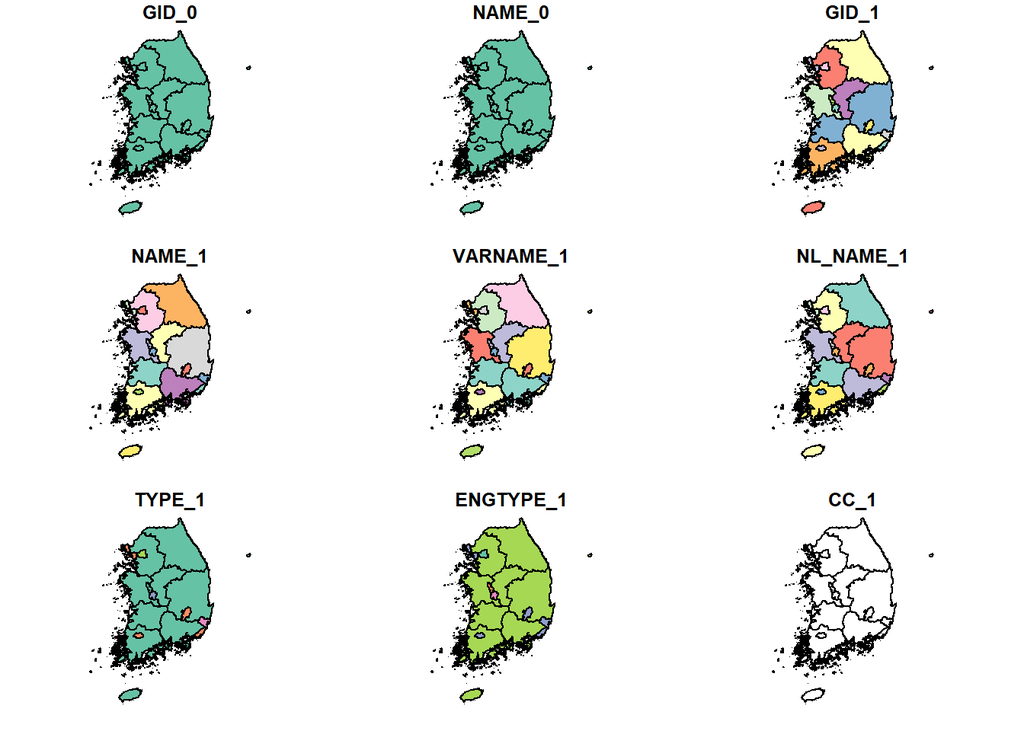

```r
sido_shp <- gadm_sp_loadCountries(fileNames = 'KOR', level = 1, basefile = './shapefiles', simplify=0.01)
fs::file_move("./shapefilesKOR_adm1.rds", "shapefiles/")
sido_shp <- read_rds("shapefiles/shapefilesKOR_adm1.rds")

sido_sf <- st_as_sf(sido_shp)
plot(sido_sf)
```

## 2.2 시도별 의사수

KOSIS에서 [`시도별 의료인력 현황`](https://kosis.kr/statHtml/statHtml.do?orgId=350&tblId=TX_35003_A003) 자료를 다운로드 받아 전체 의료인수를 시도별로 정리한다.

```r
library(readxl)

doctor_dat <- read_excel("data/시도별_의료인력_현황_20200905224937.xlsx", sheet= "데이터", skip = 3)

doctor_df <- doctor_dat %>%
  select(1,2,3) %>%
  set_names(c("시도", "시도명", "의사수")) %>%
  arrange(desc(의사수))

doctor_df
```

```
# A tibble: 17 x 3
   시도  시도명         의사수
   <chr> <chr>           <dbl>
 1 서울  서울특별시     107232
 2 경기  경기도          86060
 3 부산  부산광역시      34495
 4 경남  경상남도        26074
 5 대구  대구광역시      23401
 6 인천  인천광역시      22173
 7 경북  경상북도        18267
 8 광주  광주광역시      16467
 9 전북  전라북도        16297
10 전남  전라남도        16040
11 대전  대전광역시      14586
12 충남  충청남도        13168
13 강원  강원도          11373
14 충북  충청북도        10654
15 울산  울산광역시       8218
16 제주  제주특별자치도   5317
17 세종  세종특별자치시    973
```

## 2.3 데이터 병합

“시도명”을 기준변수로 삼아 지도와 의사 데이터프레임(`doctor_df`)를 병합시킨다.

```r
sido_doctor_sf <- sido_sf %>%
  select(GID_0, NL_NAME_1, geometry) %>%
  separate(NL_NAME_1, into = c("시도명", "구분자", "한자명"), sep =" ") %>%
  mutate(`시도명` = str_remove_all(`시도명`, " ")) %>%
  left_join(doctor_df, by="시도명")

sido_doctor_sf
```

[output not shown]

## 2.4 의사수 시각화

`ggplot`의 `geom_sf()`를 사용해서 시각화를 한다. `sido_doctor_sf`은 list-column으로 `geometry` 지도 정보를 담고 있는 데이터프레임이다.

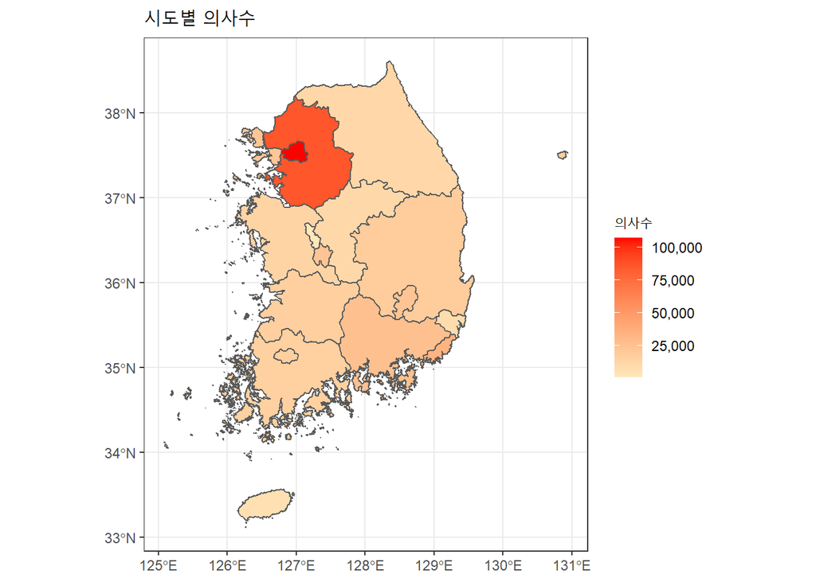

```r
sido_doctor_sf %>%
  ggplot(aes(fill=의사수)) +
    geom_sf() +
    theme_bw(base_family="NanumGothic") +
    labs(title="시도별 의사수") +
    theme(legend.position = "right") +
    scale_fill_gradient(low = "wheat1", high = "red", name = "의사수", labels = scales::comma)
```

데이터 과학자 [이광춘](https://github.com/statkclee/) 저작

*kwangchun.lee.7@gmail.com*